# BIOL3207 Data Report 2

u6956268

2022-10-31

Here is my [GitHub Repository](https://github.com/nicolelehmann/BIOL3207_Report2)

#### Load required packages

```r
library(pacman)
p_load(bookdown, tidyverse, flextable, metafor, orchaRd)
```

#### Summary statistics for Clark et al. data

```r
data <- read_csv("OA_activitydat_20190302_BIOL3207.csv")
data_clean <- data[which(complete.cases(data)),] # Remove data points which are incomplete
data_clean <- select(data_clean, -...1) # Remove irrelevant column which just doubles the row number

summary_stats <- data_clean %>% group_by(species, treatment) %>% summarise(n(), mean(activity), sd(activity))
summary_stats <- pivot_wider(data=summary_stats, names_from="treatment", values_from=c("n()", "mean(activity)", "sd(activity)"))
summary_stats
```

```
## # A tibble: 6 × 7
## # Groups:   species [6]
##   species   `n()_CO2` `n()_control` `mean(activity)_CO2` `mean(activity)_contr…`
##   <chr>         <int>         <int>                <dbl>                   <dbl>
## 1 acantho          86            90                 27.3                    28.9
## 2 ambon            22            21                 18.4                    17.3
## 3 chromis          14            20                 24.8                    26.1
## 4 humbug           62            65                 40.3                    34.9
## 5 lemon            19            30                 26.0                    19.8
## 6 whitedams        60            61                 24.5                    26.6
## # … with 2 more variables: `sd(activity)_CO2` <dbl>,
## #   `sd(activity)_control` <dbl>
```

#### Merge summary statistics with the rest of the paper meta-data

```r
clark_data <- read_csv("clark_paper_data.csv")
```

```r
clark_data <- clark_data %>% slice(rep(1:n(), each = 6)) #Copy row of info 6 times according to format of meta-analysis data set

clark_data <- mutate(clark_data, Species=summary_stats$species, .after=10)
clark_data[which(clark_data$Species=="acantho"),]$Species <- "Acanthochromis polyacanthus"
clark_data[which(clark_data$Species=="ambon"),]$Species <- "Pomacentrus amboinensis"
clark_data[which(clark_data$Species=="chromis"),]$Species <- "Chromis atripectoralis"
clark_data[which(clark_data$Species=="humbug"),]$Species <- "Dascyllus aruanus"
clark_data[which(clark_data$Species=="lemon"),]$Species <- "Pomacentrus moluccensis"
clark_data[which(clark_data$Species=="whitedams"),]$Species <- "Dischistodus perspicillatus"

clark_data <- mutate(clark_data,
                    ctrl.n=summary_stats$`n()_control`,
                    ctrl.mean=summary_stats$`mean(activity)_control`,
                    ctrl.sd=summary_stats$`sd(activity)_control`,
                    oa.n=summary_stats$`n()_CO2`,
                    oa.mean=summary_stats$`mean(activity)_CO2`,
                    oa.sd=summary_stats$`sd(activity)_CO2`)
flextable(clark_data)
```

| Study | Authors | Year (online) | Year (print) | Title | Journal | Pub year IF | 2017 IF | Average n | Effect type | Species | Climate (FishBase) | Env cue/stimulus? | Cue/stimulus type | Behavioural metric | Life stage | ctrl.n | ctrl.mean | ctrl.sd | oa.n | oa.mean | oa.sd |
| --- | --- | --- | --- | --- | --- | --- | --- | --- | --- | --- | --- | --- | --- | --- | --- | --- | --- | --- | --- | --- | --- |
| a92 | Clark et al | 2,020 | 2,020 | Ocean acidification does not impair the behaviour of coral reef fishes | Nature | 69.5 | 41.58 | 45 | Weak | Acanthochromis polyacanthus | Trop | No |  | Activity | Adult | 90 | 28.92639 | 11.246347 | 86 | 27.30042 | 10.415559 |
| a92 | Clark et al | 2,020 | 2,020 | Ocean acidification does not impair the behaviour of coral reef fishes | Nature | 69.5 | 41.58 | 45 | Weak | Pomacentrus amboinensis | Trop | No |  | Activity | Adult | 21 | 17.34102 | 11.451588 | 22 | 18.39429 | 12.200326 |
| a92 | Clark et al | 2,020 | 2,020 | Ocean acidification does not impair the behaviour of coral reef fishes | Nature | 69.5 | 41.58 | 45 | Weak | Chromis atripectoralis | Trop | No |  | Activity | Adult | 20 | 26.09986 | 9.125352 | 14 | 24.78010 | 10.975005 |
| a92 | Clark et al | 2,020 | 2,020 | Ocean acidification does not impair the behaviour of coral reef fishes | Nature | 69.5 | 41.58 | 45 | Weak | Dascyllus aruanus | Trop | No |  | Activity | Adult | 65 | 34.91652 | 13.867278 | 62 | 40.28306 | 11.915992 |
| a92 | Clark et al | 2,020 | 2,020 | Ocean acidification does not impair the behaviour of coral reef fishes | Nature | 69.5 | 41.58 | 45 | Weak | Pomacentrus moluccensis | Trop | No |  | Activity | Adult | 30 | 19.79766 | 12.256353 | 19 | 26.04157 | 10.957164 |
| a92 | Clark et al | 2,020 | 2,020 | Ocean acidification does not impair the behaviour of coral reef fishes | Nature | 69.5 | 41.58 | 45 | Weak | Dischistodus perspicillatus | Trop | No |  | Activity | Adult | 61 | 26.58624 | 10.936592 | 60 | 24.45733 | 9.950437 |

#### Merge Clark et al. data with the meta-analysis data set

```r
meta_data <- read_csv("ocean_meta_data.csv")
clark_data$`Pub year IF` <- as.character(clark_data$`Pub year IF`) #Changing variable class to character to match meta-analysis data set
clark_data$`2017 IF` <- as.character(clark_data$`2017 IF`) #Changing variable class to character to match meta-analysis data set

meta_data <- full_join(meta_data, clark_data)
```

[output not shown]

```r
summary(meta_data)
```

```
##     Study             Authors          Year (online)   Year (print)
##  Length:824         Length:824         Min.   :2009   Min.   :2009
##  Class :character   Class :character   1st Qu.:2012   1st Qu.:2013
##  Mode  :character   Mode  :character   Median :2015   Median :2015
##                                        Mean   :2015   Mean   :2015
##                                        3rd Qu.:2017   3rd Qu.:2018
##                                        Max.   :2020   Max.   :2020
##     Title             Journal          Pub year IF          2017 IF
##  Length:824         Length:824         Length:824         Length:824
##  Class :character   Class :character   Class :character   Class :character
##  Mode  :character   Mode  :character   Mode  :character   Mode  :character
##
##
##
##    Average n      Effect type          Species          Climate (FishBase)
##  Min.   :  4.00   Length:824         Length:824         Length:824
##  1st Qu.: 12.00   Class :character   Class :character   Class :character
##  Median : 17.00   Mode  :character   Mode  :character   Mode  :character
##  Mean   : 28.69
##  3rd Qu.: 30.00
##  Max.   :568.00
##  Env cue/stimulus?  Cue/stimulus type  Behavioural metric  Life stage
##  Length:824         Length:824         Length:824         Length:824
##  Class :character   Class :character   Class :character   Class :character
##  Mode  :character   Mode  :character   Mode  :character   Mode  :character
##
##
##
##      ctrl.n         ctrl.mean            ctrl.sd               oa.n
##  Min.   :  4.00   Min.   :   -69.78   Min.   :    0.000   Min.   :  2.00
##  1st Qu.: 10.00   1st Qu.:     1.08   1st Qu.:    1.176   1st Qu.: 11.00
##  Median : 18.00   Median :     9.52   Median :    5.867   Median : 18.00
##  Mean   : 29.14   Mean   :   435.63   Mean   :  103.754   Mean   : 29.04
##  3rd Qu.: 30.00   3rd Qu.:    43.11   3rd Qu.:   21.524   3rd Qu.: 34.00
##  Max.   :752.00   Max.   :154936.88   Max.   :25490.446   Max.   :755.00
##     oa.mean              oa.sd
##  Min.   :   -59.67   Min.   :    0.00
##  1st Qu.:     1.21   1st Qu.:    1.17
##  Median :    12.37   Median :    7.26
##  Mean   :   435.35   Mean   :  113.65
##  3rd Qu.:    43.32   3rd Qu.:   22.05
##  Max.   :157061.25   Max.   :36812.37
```

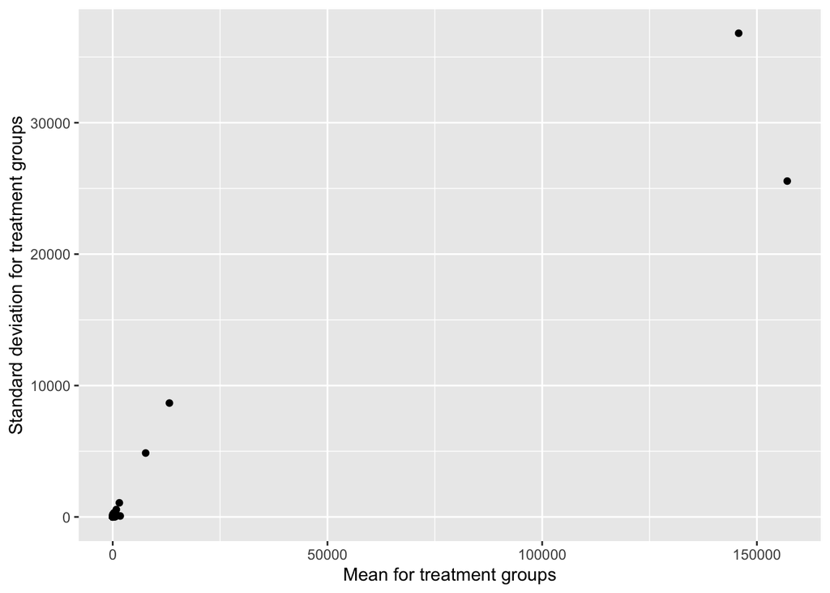

Figure 1: Means and corresponding standard deviations for each treatment condition group

```r
ggplot(meta_data, aes(x=oa.mean, y=oa.sd))+
  geom_point()+
  labs(x="Mean for treatment groups", y="Standard deviation for treatment groups")
```

From the data summary and Fig. 1 there are four clear outlier data points with very high means and standard deviations. This will dramatically skew the data means and variance if left in, so these four points will be investigated further.

```r
outliers <- meta_data %>% filter(meta_data$oa.mean > 2000)
flextable(outliers)
```

| Study | Authors | Year (online) | Year (print) | Title | Journal | Pub year IF | 2017 IF | Average n | Effect type | Species | Climate (FishBase) | Env cue/stimulus? | Cue/stimulus type | Behavioural metric | Life stage | ctrl.n | ctrl.mean | ctrl.sd | oa.n | oa.mean | oa.sd |
| --- | --- | --- | --- | --- | --- | --- | --- | --- | --- | --- | --- | --- | --- | --- | --- | --- | --- | --- | --- | --- | --- |
| a57 | Silva et al | 2,016 | 2,016 | Effects of ocean acidification on the swimming ability, development and biochemical responses of sand smelt larvae | Sci Tot Environ | 4.9 | 4.61 | 40 | No | Atherina presbyter | Subtrop | No | - | Swim speed | Larvae | 40 | 154,936.875 | 25,490.446 | 40 | 145,751.88 | 36,812.374 |
| a57 | Silva et al | 2,016 | 2,016 | Effects of ocean acidification on the swimming ability, development and biochemical responses of sand smelt larvae | Sci Tot Environ | 4.9 | 4.61 | 40 | No | Atherina presbyter | Subtrop | No | - | Swim speed | Larvae | 40 | 154,936.875 | 25,490.446 | 40 | 157,061.25 | 25,560.360 |
| a83 | Sswat et al | 2,018 | 2,018 | Growth performance and survival of larval Atlantic herring, under the combined effects of elevated temperatures and CO2 | PloS One | 2.766 | 2.766 | 9 | No | Clupea harengus | Temp | No | - | Mean activity (size standardized), 28 days | Larvae | 6 | 7,288.397 | 8,116.336 | 6 | 7,667.75 | 4,864.155 |
| a83 | Sswat et al | 2,018 | 2,018 | Growth performance and survival of larval Atlantic herring, under the combined effects of elevated temperatures and CO2 | PloS One | 2.766 | 2.766 | 9 | No | Clupea harengus | Temp | No | - | Mean activity (size standardized), 30 days | Larvae | 12 | 10,164.310 | 9,856.400 | 12 | 13,197.13 | 8,667.416 |

It seems like the outlier data points could be due to all four rows investigating the larvae life stage, could be related to the species each study looked at or could be a measurement/unit error in both of the studies. Let’s first investigate all of the larvae data.

```r
larv <- meta_data %>% filter(meta_data$`Life stage`=="Larvae")
summary(larv)
```

```
##     Study             Authors          Year (online)   Year (print)
##  Length:297         Length:297         Min.   :2009   Min.   :2009
##  Class :character   Class :character   1st Qu.:2011   1st Qu.:2012
##  Mode  :character   Mode  :character   Median :2014   Median :2014
##                                        Mean   :2014   Mean   :2014
##                                        3rd Qu.:2018   3rd Qu.:2018
##                                        Max.   :2019   Max.   :2019
##     Title             Journal          Pub year IF          2017 IF
##  Length:297         Length:297         Length:297         Length:297
##  Class :character   Class :character   Class :character   Class :character
##  Mode  :character   Mode  :character   Mode  :character   Mode  :character
##
##
##
##    Average n      Effect type          Species          Climate (FishBase)
##  Min.   :  8.00   Length:297         Length:297         Length:297
##  1st Qu.: 15.00   Class :character   Class :character   Class :character
##  Median : 18.00   Mode  :character   Mode  :character   Mode  :character
##  Mean   : 34.07
##  3rd Qu.: 35.00
##  Max.   :568.00
##  Env cue/stimulus?  Cue/stimulus type  Behavioural metric  Life stage
##  Length:297         Length:297         Length:297         Length:297
##  Class :character   Class :character   Class :character   Class :character
##  Mode  :character   Mode  :character   Mode  :character   Mode  :character
##
##
##
##      ctrl.n         ctrl.mean            ctrl.sd               oa.n
##  Min.   :  6.00   Min.   :    -2.80   Min.   :    0.000   Min.   :  6.00
##  1st Qu.: 15.00   1st Qu.:     1.14   1st Qu.:    0.488   1st Qu.: 15.00
##  Median : 22.00   Median :     6.03   Median :    2.730   Median : 22.00
##  Mean   : 34.88   Mean   :  1133.15   Mean   :  246.916   Mean   : 35.41
##  3rd Qu.: 43.00   3rd Qu.:    42.27   3rd Qu.:   17.209   3rd Qu.: 45.00
##  Max.   :752.00   Max.   :154936.88   Max.   :25490.446   Max.   :755.00
##     oa.mean              oa.sd
##  Min.   :    -0.50   Min.   :    0.00
##  1st Qu.:     1.62   1st Qu.:    0.91
##  Median :     8.86   Median :    4.05
##  Mean   :  1128.12   Mean   :  271.48
##  3rd Qu.:    48.77   3rd Qu.:   17.36
##  Max.   :157061.25   Max.   :36812.37
```

There are plenty of other data points for the Larvae life stage which seem to fit with the rest of the data, so this doesn’t seem to be the reason for the high numbers. However, the influence of these outlier points on the data is made obvious by the dramatic difference between mean and median values for many of the variables. Let’s investigate the fish species for each of the four points.

```r
AP_CH <- meta_data %>% filter(meta_data$Species=="Atherina presbyter"|meta_data$Species=="Clupea harengus")
summary(AP_CH)
```

```
##     Study             Authors          Year (online)   Year (print)
##  Length:24          Length:24          Min.   :2015   Min.   :2015
##  Class :character   Class :character   1st Qu.:2015   1st Qu.:2015
##  Mode  :character   Mode  :character   Median :2016   Median :2016
##                                        Mean   :2016   Mean   :2016
##                                        3rd Qu.:2016   3rd Qu.:2016
##                                        Max.   :2018   Max.   :2018
##     Title             Journal          Pub year IF          2017 IF
##  Length:24          Length:24          Length:24          Length:24
##  Class :character   Class :character   Class :character   Class :character
##  Mode  :character   Mode  :character   Mode  :character   Mode  :character
##
##
##
##    Average n     Effect type          Species          Climate (FishBase)
##  Min.   : 9.00   Length:24          Length:24          Length:24
##  1st Qu.:15.00   Class :character   Class :character   Class :character
##  Median :20.00   Mode  :character   Mode  :character   Mode  :character
##  Mean   :20.75
##  3rd Qu.:25.00
##  Max.   :40.00
##  Env cue/stimulus?  Cue/stimulus type  Behavioural metric  Life stage
##  Length:24          Length:24          Length:24          Length:24
##  Class :character   Class :character   Class :character   Class :character
##  Mode  :character   Mode  :character   Mode  :character   Mode  :character
##
##
##
##      ctrl.n        ctrl.mean            ctrl.sd               oa.n
##  Min.   : 6.00   Min.   :     0.12   Min.   :    0.073   Min.   : 6.00
##  1st Qu.:12.00   1st Qu.:     0.64   1st Qu.:    0.143   1st Qu.:12.00
##  Median :19.00   Median :     4.22   Median :    3.349   Median :19.00
##  Mean   :20.42   Mean   : 13647.77   Mean   : 2877.907   Mean   :21.33
##  3rd Qu.:25.00   3rd Qu.:    40.44   3rd Qu.:   18.222   3rd Qu.:26.00
##  Max.   :43.00   Max.   :154936.88   Max.   :25490.446   Max.   :43.00
##     oa.mean              oa.sd
##  Min.   :     0.12   Min.   :    0.03
##  1st Qu.:     0.68   1st Qu.:    0.14
##  Median :     3.90   Median :    3.16
##  Mean   : 13493.31   Mean   : 3167.20
##  3rd Qu.:    25.65   3rd Qu.:   17.93
##  Max.   :157061.25   Max.   :36812.37
```

Again there is other data for both species which fits with the rest of the data. Therefore, it seems like these two studies have extremely high values possibly due to a measurement difference or a unit error. Either way, it is clear that there has been an error in the standardisation of values for the meta-analysis. These are the only data points for each of the studies. As such, it seems reasonable to exclude both of these studies entirely from the meta-data.

```r
meta_data <- meta_data %>% filter(meta_data$Title!="Effects of ocean acidification on the swimming ability, development and biochemical responses of sand smelt larvae" & meta_data$Title!="Growth performance and survival of larval Atlantic herring, under the combined effects of elevated temperatures and CO2")
```

#### Calculate the log response ratio (lnRR) effect sizes

```r
meta_data <- metafor::escalc(measure = "ROM",
                                n1i = ctrl.n, n2i = oa.n,
                                m1i = ctrl.mean, m2i = oa.mean,
                                sd1i = ctrl.sd, sd2i = oa.sd,
                                var.names=c("lnRR","V_lnRR"),
                                data = meta_data)
meta_data <- meta_data %>% mutate(residual = 1:n())
```

```r
highvar <- meta_data %>% filter(meta_data$V_lnRR>50)
flextable(highvar)
```

| Study | Authors | Year..online. | Year..print. | Title | Journal | Pub.year.IF | X2017.IF | Average.n | Effect.type | Species | Climate..FishBase. | Env.cue.stimulus. | Cue.stimulus.type | Behavioural.metric | Life.stage | ctrl.n | ctrl.mean | ctrl.sd | oa.n | oa.mean | oa.sd | lnRR | V_lnRR | residual |
| --- | --- | --- | --- | --- | --- | --- | --- | --- | --- | --- | --- | --- | --- | --- | --- | --- | --- | --- | --- | --- | --- | --- | --- | --- |
| a12 | Ferrari et al | 2,012 | 2,012 | Effects of ocean acidification on visual risk assessment in coral reef fishes | Funct Ecol | 4.861 | 5.491 | 25 | Strong | Pomacentrus amboinensis | Trop | Yes | Food | Prop decrease line crosses, 850 uatm | Juvenile | 25 | 0.5480 | 0.3424 | 25 | 0.0010 | 0.7411 | 6.306275 | 21,969.18 | 163 |
| a22 | L<9a>nnstedt et al | 2,013 | 2,013 | Ocean acidification and responses to predators: can sensory redundancy reduce the apparent impacts of elevated CO2 on fish? | Ecol Evol | 1.658 | 2.34 | 28 | Strong | Pomacentrus amboinensis | Trop | No | - | Mean change in shelter use, saltwater control, Fig1 | Larvae | 29 | 1.6440 | 8.8532 | 29 | 0.0001 | 6.4407 | 9.707473 | 143,043,506.14 | 220 |
| a80 | Raby et al | 2,018 | 2,018 | Exposure to elevated carbon dioxide does not impair shortterm swimming behaviour or shelter-seeking in a predatory coral-reef fish | J Fish Biol | 1.702 | 1.702 | 11 | No | Cephalopholis cyanostigma | Trop | Yes | Habitat | Immobile at surface | Adult | 10 | 0.0001 | 0.4533 | 11 | 0.0001 | 0.7104 | 0.000000 | 6,642,701.26 | 671 |

```r
lowvar <- meta_data %>% filter(meta_data$V_lnRR<=0.0001)
flextable(lowvar)
```

| Study | Authors | Year..online. | Year..print. | Title | Journal | Pub.year.IF | X2017.IF | Average.n | Effect.type | Species | Climate..FishBase. | Env.cue.stimulus. | Cue.stimulus.type | Behavioural.metric | Life.stage | ctrl.n | ctrl.mean | ctrl.sd | oa.n | oa.mean | oa.sd | lnRR | V_lnRR | residual |
| --- | --- | --- | --- | --- | --- | --- | --- | --- | --- | --- | --- | --- | --- | --- | --- | --- | --- | --- | --- | --- | --- | --- | --- | --- |
| a1 | Munday et al | 2,009 | 2,009 | Ocean acidification impairs olfactory discrimination and homing ability of marine fish. | PNAS | 9.432 | 9.504 | 27 | Strong | Amphiprion percula | Trop | Yes | Kin | % time in Non-parent vs Seawater cue | Larvae | 30 | 90.876 | 3.9984 | 20 | 99.8180 | 0.0045 | -0.09385259 | 0.000064528786944683 | 6 |
| a2 | Dixson et al | 2,009 | 2,010 | Ocean acidification disrupts the innate ability of fish to detect predator olfactory cues | Ecol Lett | 10.318 | 9.137 | 15 | Strong | Amphiprion percula | Trop | Yes | Predator | % time in non-predator cue, settlement stg, untreat vs. non-pred 1 | Larvae | 45 | 50.270 | 0.0007 | 45 | 99.9999 | 0.0007 | -0.68776071 | 0.000000000005397785 | 16 |
| a2 | Dixson et al | 2,009 | 2,010 | Ocean acidification disrupts the innate ability of fish to detect predator olfactory cues | Ecol Lett | 10.318 | 9.137 | 15 | Strong | Amphiprion percula | Trop | Yes | Predator | % time in non-predator cue, settlement stg, untreat vs. non-pred 2 | Larvae | 45 | 50.811 | 0.0007 | 45 | 99.9999 | 0.0007 | -0.67705632 | 0.000000000005306517 | 17 |
| a24 | Munday et al | 2,012 | 2,013 | Elevated CO2 affects the behavior of an ecologically and economically important coral reef fish | Mar Biol | 2.468 | 2.215 | 13 | Strong | Plectropomus leopardus | Trop | Yes | Shelter | Mean line crosses, 570 uatm | Juvenile | 10 | 4.969 | 0.0001 | 10 | 9.9380 | 0.0010 | -0.69314718 | 0.000000001053016932 | 255 |
| a54 | Pimentel et al | 2,016 | 2,016 | Foraging behaviour, swimming performance and malformations of early stages of commercially important fishes under ocean acidification and warming | Clim Change | 3.496 | 3.537 | 12 | Strong | Argyrosomus regius | Subtrop | Yes | Food | Attack % | Larvae | 12 | 4.208 | 0.0003 | 12 | 3.4920 | 0.0003 | 0.18651284 | 0.000000001038608346 | 497 |
| a66 | Pistevos et al | 2,016 | 2,017 | Ocean acidification alters temperature and salinity preferences in larval fish | Oecologia | 3.13 | 3.127 | 20 | Strong | Lates calcarifer | Trop | Yes | Physical Seawater | % time in warm water | Larvae | 11 | 51.163 | 1.4023 | 14 | 63.9350 | 0.9322 | -0.22285033 | 0.000083478086372069 | 560 |
| a66 | Pistevos et al | 2,016 | 2,017 | Ocean acidification alters temperature and salinity preferences in larval fish | Oecologia | 3.13 | 3.127 | 20 | Strong | Lates calcarifer | Trop | Yes | Physical Seawater | % time in estuary cue | Larvae | 36 | 55.000 | 0.5208 | 37 | 72.5000 | 0.4110 | -0.27625338 | 0.000003359230014366 | 562 |

Filter out high and low variances

```r
meta_data <- meta_data %>% filter(meta_data$V_lnRR<50)
meta_data <- meta_data %>% filter(meta_data$V_lnRR>0.0001)
```

```r
model <- metafor::rma.mv(lnRR~1, V=V_lnRR,
                         method="REML",
                         random=list(~1|Study,
                                     ~1|Life.stage),
                         dfs = "contain",
                         test="t",
                         data=meta_data)
model
```

```
##
## Multivariate Meta-Analysis Model (k = 787; method: REML)
##
## Variance Components:
##
##             estim    sqrt  nlvls  fixed      factor
## sigma^2.1  0.1369  0.3700     90     no       Study
## sigma^2.2  0.0000  0.0002      4     no  Life.stage
##
## Test for Heterogeneity:
## Q(df = 786) = 73608.9504, p-val < .0001
##
## Model Results:
##
## estimate      se    tval  df    pval    ci.lb   ci.ub
##   0.0396  0.0408  0.9699   3  0.4036  -0.0902  0.1694
##
## ---
## Signif. codes:  0 '***' 0.001 '**' 0.01 '*' 0.05 '.' 0.1 ' ' 1
```

#### Multivariate model heterogeneity tests

```r
orchaRd::i2_ml(model, data = meta_data)
```

```
##      I2_Total      I2_Study I2_Life.stage
##  9.652614e+01  9.652613e+01  1.732515e-05
```

```r
predict(model)
```

```
##
##    pred     se   ci.lb  ci.ub   pi.lb  pi.ub
##  0.0396 0.0408 -0.0902 0.1694 -1.1452 1.2244
```

The overall meta-analytic mean is 0.0396. This means that for every 1 increase in the control mean, the treatment mean increases by 1.0396. The 95% confidence interval is -0.0902 to 0.1694. This confidence interval includes 0 which is predicted under the null hypothesis, so there is no statistically significant difference between the treatment and control groups. The null hypothesis is retained that ocean acidification does not have any effect on behaviour.

As seen in Fig. 2, although there is some variability between studies there is a general linear trend between the means of the control and treatment groups. For example, if the mean of the control group is 500, then the mean of the treatment group is also likely to be around 500. This shows that there is no statistical difference between the control and treatment groups, so there is no indication that ocean acidification alters behaviours.

There is heterogeneity among effects, indicated by Q=73,608.95, df=786, p=<0.0001 (highly significant). The proportion of variance among effects after removing sampling variation is 96.5%. An I^2 above 75% indicates a high level of heterogeneity. Only about 3.5% of variation seen across effects is driven by sampling variance. Differences between studies explains 96.5% of the effect size variation, and differences between Life stage explains 0.000017% of the effect size variation. The prediction intervals of -1.1452 to 1.2244 give the range of effect size values that would be expected 95% of the time from re-sampling the population. This gives a measure for how variable the effects are likely to be, and an interval of around -1 to 1 is a relatively narrow interval so there should be relatively little variation in the effect size obtained if the population was re-sampled in additional experiments.

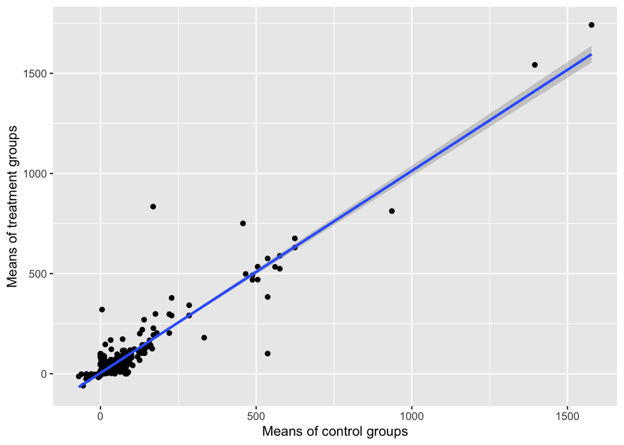

Figure 2: Linear relationship between the mean of control and treatment groups in each study

```r
ggplot(meta_data, aes(x=ctrl.mean, y=oa.mean))+
  geom_point()+
  geom_smooth(method = "lm")+
  labs(x="Means of control groups", y="Means of treatment groups")
```

```r
lifestage_model <- metafor::rma.mv(lnRR~Life.stage, V=V_lnRR,
                         method="REML",
                         random=list(~1|Study),
                         dfs = "contain",
                         test="t",
                         data=meta_data)
lifestage_model
```

```
##
## Multivariate Meta-Analysis Model (k = 787; method: REML)
##
## Variance Components:
##
##             estim    sqrt  nlvls  fixed  factor
## sigma^2    0.1405  0.3749     90     no   Study
##
## Test for Residual Heterogeneity:
## QE(df = 783) = 71559.5307, p-val < .0001
##
## Test of Moderators (coefficients 2:4):
## F(df1 = 3, df2 = 86) = 0.3434, p-val = 0.7940
##
## Model Results:
##
##                         estimate      se     tval  df    pval    ci.lb   ci.ub
## intrcpt                   0.0946  0.0835   1.1327  86  0.2605  -0.0714  0.2606
## Life.stageJuvenile       -0.0450  0.1089  -0.4136  86  0.6802  -0.2615  0.1714
## Life.stageLarvae         -0.1047  0.1075  -0.9735  86  0.3330  -0.3185  0.1091
## Life.stageNot provided   -0.0120  0.2347  -0.0513  86  0.9592  -0.4786  0.4545
##
## intrcpt
## Life.stageJuvenile
## Life.stageLarvae
## Life.stageNot provided
##
## ---
## Signif. codes:  0 '***' 0.001 '**' 0.01 '*' 0.05 '.' 0.1 ' ' 1
```

This is a multivariate model accounting for Life stage as a potential variable contributing to the effect sizes obtained in each study. However, as seen in the estimates, the adult life stage effect size is very close to 0, and although the juvenile, larvae and not provided life stages all have a slightly smaller effect size than the adult, none of these are even close to being significantly different as they are all very close to 0 as well. It doesn’t appear that life stage is affecting the effect size.

#### Forest plot

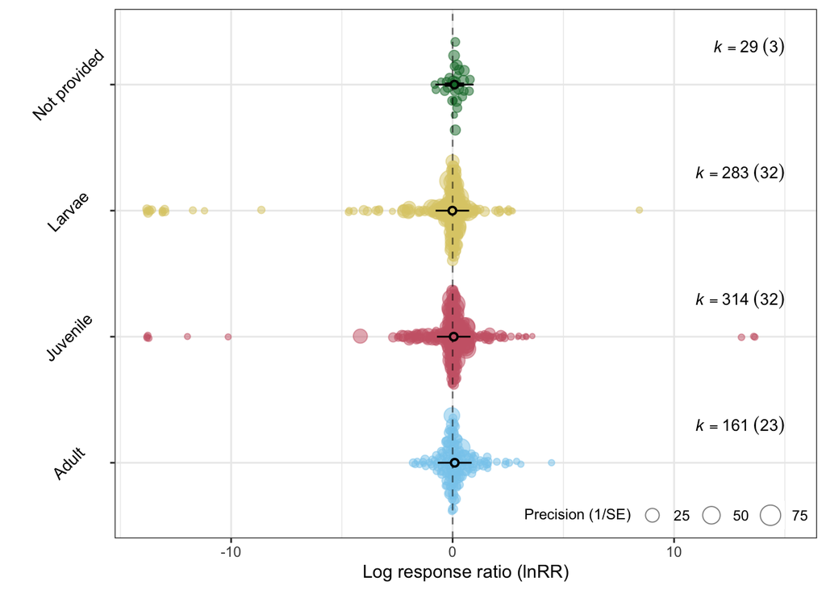

Figure 3: Forest plot showing the range of log response ratios with the point size indicating the precision of each effect size value

```r
orchaRd::orchard_plot(lifestage_model, mod="Life.stage", group = "Study", data = meta_data, xlab = "Log response ratio (lnRR)", angle = 45)
```

In Fig. 3, K indicates the number of effect sizes in the group and the brackets indicate the number of studies in the group. The size of the effect is scaled by the precision of each effect size value. It is clear that most of the studies are sitting around a log response ratio of 0, leading to mean estimates around 0 which indicates no difference between the control and treatment groups. Ocean acidification does not seem to have an effect on behaviour. Additionally, although the larvae and juvenile life stages have greater variation in log response ratio than the adult or not provided life stages, there does not seem to be any particular difference in log response ratio between studies according to the life stage of the fish.

#### Funnel plot

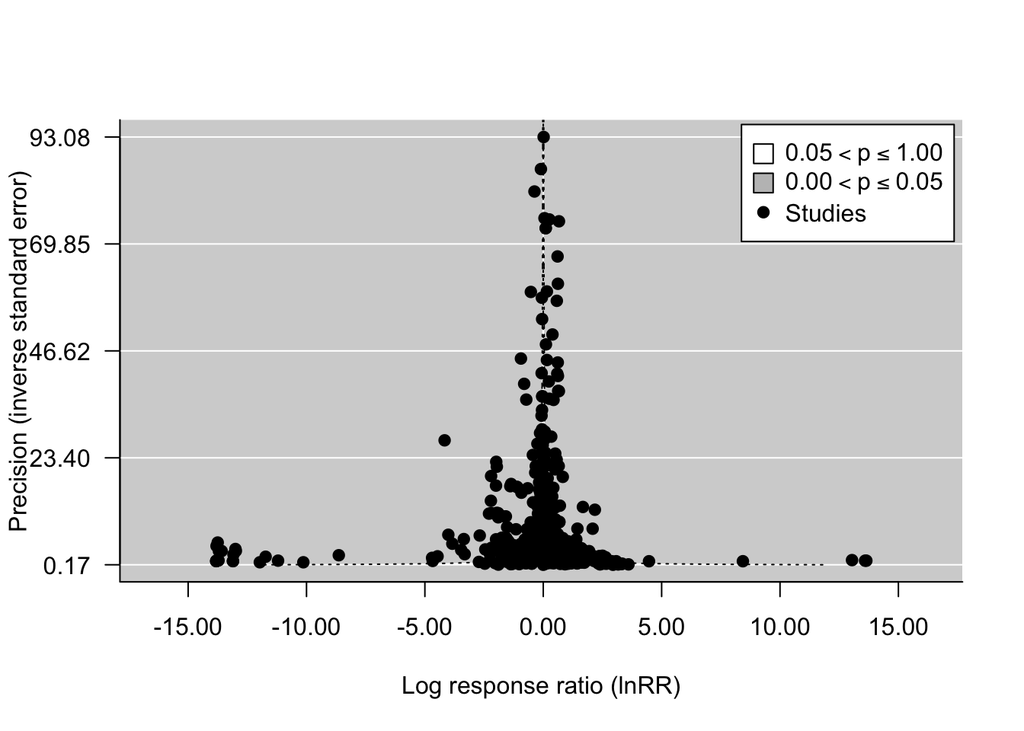

Figure 4: Funnel plot of log response ratio and precision

```r
metafor::funnel(x = meta_data$lnRR, vi = meta_data$V_lnRR,
                yaxis = "seinv", digits = 2,
                shade = c("white", "gray 75"), las = 1,
                xlab = "Log response ratio (lnRR)", ylab = "Precision (inverse standard error)",
                legend = TRUE)
```

From the funnel plot in Fig. 4, it seems that there is some publication bias towards negative log response ratios. There is a gap on the bottom right hand side of the funnel plot where low precision studies (potentially due to being under-powered) would have found a positive log response ratio. This does not mean that positive log response ratios were not found in studies, but indicates that these studies for whatever reason did not get published, whereas the studies with negative log response ratios were highly published even when they were low precision.

#### Time-lag plot

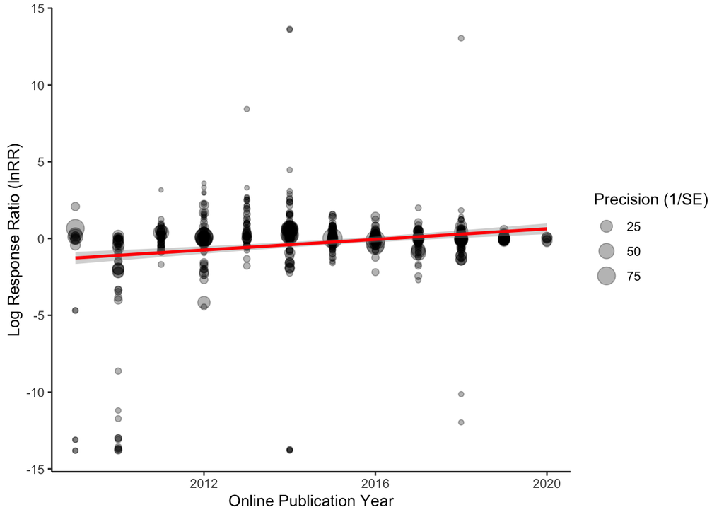

Figure 5: Time-lag plot of the log response ratio and online publication year with the point size indicating the level of precision

```r
ggplot(meta_data, aes(y = lnRR, x = Year..online., size = 1/sqrt(V_lnRR))) +
  geom_point(alpha = 0.30) +
  geom_smooth(method = lm, col = "red", show.legend = FALSE) +
  labs(x = "Online Publication Year", y = "Log Response Ratio (lnRR)", size = "Precision (1/SE)") +
  theme_classic()
```

#### Formal meta-regression model with year as a moderator

```r
meta_data <- meta_data  %>% mutate(Year_c = Year..online. - mean(Year..online.))
#metafor::rma(yi = lnRR, vi = V_lnRR, method = "FE", data = meta_data)
metafor::rma.mv(lnRR ~ Year_c, V = V_lnRR,
                   method="REML",
                   random=list(~1|residual),
                   dfs = "contain",
                   test="t",
                   data=meta_data)
```

```
##
## Multivariate Meta-Analysis Model (k = 787; method: REML)
##
## Variance Components:
##
##             estim    sqrt  nlvls  fixed    factor
## sigma^2    4.7682  2.1836    787     no  residual
##
## Test for Residual Heterogeneity:
## QE(df = 785) = 73167.2181, p-val < .0001
##
## Test of Moderators (coefficient 2):
## F(df1 = 1, df2 = 785) = 40.5251, p-val < .0001
##
## Model Results:
##
##          estimate      se     tval   df    pval    ci.lb    ci.ub
## intrcpt   -0.2688  0.0801  -3.3551  785  0.0008  -0.4261  -0.1115  ***
## Year_c     0.1806  0.0284   6.3659  785  <.0001   0.1249   0.2363  ***
##
## ---
## Signif. codes:  0 '***' 0.001 '**' 0.01 '*' 0.05 '.' 0.1 ' ' 1
```

#### Formal meta-regression model that includes inverse sampling variance (1/variance of log response ratio) to test for file-drawer biases

```r
# Including sampling variance as moderator

metareg_time <- rma.mv(lnRR ~ Year_c, V = 1/V_lnRR,
                    random = list(~1|Study,
                                  ~1|residual),
                    test = "t", dfs = "contain",
                    data = meta_data)
summary(metareg_time)
```

```
##
## Multivariate Meta-Analysis Model (k = 787; method: REML)
##
##     logLik    Deviance         AIC         BIC        AICc
## -2390.2462   4780.4924   4788.4924   4807.1552   4788.5437
##
## Variance Components:
##
##             estim    sqrt  nlvls  fixed    factor
## sigma^2.1  1.9204  1.3858     90     no     Study
## sigma^2.2  7.1610  2.6760    787     no  residual
##
## Test for Residual Heterogeneity:
## QE(df = 785) = 4260.7573, p-val < .0001
##
## Test of Moderators (coefficient 2):
## F(df1 = 1, df2 = 88) = 7.3360, p-val = 0.0081
##
## Model Results:
##
##          estimate      se     tval  df    pval    ci.lb   ci.ub
## intrcpt   -0.3246  0.2641  -1.2292  88  0.2223  -0.8494  0.2002
## Year_c     0.2676  0.0988   2.7085  88  0.0081   0.0712  0.4639  **
##
## ---
## Signif. codes:  0 '***' 0.001 '**' 0.01 '*' 0.05 '.' 0.1 ' ' 1
```

```r
# How much variation does time when results were published explain in lnRR?
r2_time <- orchaRd::r2_ml(metareg_time)
r2_time
```

```
##    R2_marginal R2_conditional
##     0.05885589     0.25787258
```

#### Written paragraph about the meta-regression results. What type of publication bias, if any, appears to be present in the data? If publication bias is present, what does it mean and what might be contributing to such bias?

The log-response ratio is definitely converging on the value of 0 over time. In the first couple of years, there is a strong bias towards studies with negative log response ratios. Then in the middle there is a bias towards studies with positive log response ratios which drags the trend towards 0. By 2020, the studies are finding log response ratios close to 0. Also note that the early studies that found more extreme log response ratios typically have lower precision, whereas the higher precision studies are closer to a log response ratio of 0.

#### Identify any studies contributing to publication bias. How do your updated meta-analysis results compare with a meta-analysis by Clement et al? Are there any concerns about these studies? If so, describe using references to existing papers what concerns have been raised?

The study that stands out in the funnel plot above as having a relatively high negative log response ratio and relatively high precision compared to other studies is likely contributing to publication bias. With high precision and a significant effect size, this study likely had high impact when it was published. However, the meta-analysis has found that this is a false finding.

A meta-analysis by Clements et al. of the impacts of ocean acidification on fishe behaviour looked at 91 studies. They concluded that the large effects described in initial studies have disappeared in subsequent studies. This is the same conclusion that was found in this meta-analysis. Clements et al. explained the results through findings that the initial studies typically had small sample sizes but were published in high-impact journals and therefore had a large influence on the field.